# Mangrove Loss and Environmental Health

Luke Wolcott

April 10, 2017

Continuing from the last two weeks, I’m looking at the change in mangrove forest area between 2000-2012, as an indication of the health of these forests and the level of environmental stewardship of the corresponding country.

Mangrove data from [here](http://faculty.salisbury.edu/~sehamilton/mangroves/); environmental health/vitality data from the Environmental Performance Index project [here](http://epi.yale.edu/downloads) (metadata PDF [here](http://epi.yale.edu/sites/default/files/Yale%20EPI%20Metadata_2016.pdf)). See my last two week’s reports for more background.

The specific question is: **Which evironmental factors correlate with changes in mangrove forest health?** The answer, as we’ll see, may be “Access to Sanitation” and “Fish Stocks”.

### Merging the tables

```
##  [1] "New Caledonia"           "Palau"
##  [3] "Cayman Islands"          "Puerto Rico"
##  [5] "Micronesia, FS"          "Virgin Islands, U.S."
##  [7] "Saint Lucia"             "Curacao"
##  [9] "Virgin Islands, British" "St.Vincent & Grenadines"
## [11] "Turks and Caicos "       "Aruba"
## [13] "Anguilla"                "Saint Martin"
## [15] "Bermuda"
```

### Environmental indicators

For the remaining 86 countries, the EPI table gives 37 different indicators of “environmental health” and “ecosystem vitality”.

Several of them are simply weighted combinations of others, so we can throw these out.

Next we need to deal with missing values. The 10 NAs for Nitrogen.Balance and Nitrogen.Use.Efficiency are, according to the metadata, for ten countries that have minimal agricultural output. We’ll fill these in with the mean values.

Since 25 out of the 86 rows have NAs for Trend.in.Carbon.Intensity, I don’t know how to impute values and I’m going to remove this column. In the end, here are our column names.

```
##  [1] "ISO_3_Num"
##  [2] "Percent.Change.in.Mangrove.Forest"
##  [3] "Country"
##  [4] "X2016.EPI.Score"
##  [5] "X10.Year.Percent.Change"
##  [6] "Environmental.Risk.Exposure"
##  [7] "Household.Air.Quality"
##  [8] "Household.Air.Quality...Risk.Exposure"
##  [9] "Air.Pollution...Average.Exposure.to.PM2.5"
## [10] "Air.Pollution...Average.Exposure.to.PM2.5...Risk.Exposure"
## [11] "Air.Pollution...Average.PM2.5.Exceedance"
## [12] "Air.Pollution...Average.Exposure.to.NO2"
## [13] "Access.to.Sanitation"
## [14] "Unsafe.Sanitation..Risk.Exposure"
## [15] "Access.to.Drinking.Water"
## [16] "Unsafe.Drinking.Water.Quality..Risk.Exposure"
## [17] "Wastewater.Treatment"
## [18] "Nitrogen.Use.Efficiency"
## [19] "Nitrogen.Balance"
## [20] "Tree.Cover.Loss"
## [21] "Fish.Stocks"
## [22] "Terrestrial.Protected.Areas..National.Biome.Weights."
## [23] "Terrestrial.Protected.Areas..Global.Biome.Weights."
## [24] "Marine.Protected.Areas"
## [25] "Species.Protection..National."
## [26] "Species.Protection..Global."
## [27] "Trend.in.CO2.Emissions.per.KwH"
## [28] "Access.to.Electricity"
```

### Linear regression

Let’s use the environmental indicators (columns 4-28) to fit for the values of `Percent.Change.in.Mangrove.Forest`.

The only variables with significant p-values are `Air.Pollution...Average.PM2.5.Exceedance` (p-value 0.0212) and `Air.Pollution...Average.Exposure.to.NO2` (p-value 0.0676). The first is a measure of how often the PM2.5 particulate matter was above certain human health targets. The second measures levels of nitrogen dioxide, another type of air pollution. While I find this analysis disappointing, perhaps it indicates that mangroves are more sensitive to air quality than to other environmental health indicators.

### Removing outliers

Or, we can take the position that our model has some issues and we need to remove some outliers. Here are the countries with the highest leverage based on `dffits`, which measures the change in the predicted response if we remove that country. I also display their actual Percent.Change.in.Mangrove.

```
##                  7        37     73        3        55                45
## Country    Myanmar Guatemala Taiwan Malaysia Sri Lanka Brunei Darussalam
## dffits      -3.252    -2.845 -2.066   -1.509     1.429             1.275
## MangChange   -8.42    -6.411 -3.571   -4.887    -1.203            -0.787
```

The function `cooks.distance` calculates the overall change in regression coefficients when a country is omitted from the calculation. Here are the countries with the largest `cooks.distance`.

```
##                     7          37        73           3          55
## Country       Myanmar   Guatemala    Taiwan    Malaysia   Sri Lanka
## CooksDist 0.320397056 0.246735278 0.1536278 0.079932539 0.075605673
##                          45
## Country   Brunei Darussalam
## CooksDist       0.062255164
```

**Since the mean for mangrove change is -1.035%, we start to get the picture that the four countries Myanmar, Guatemala, Taiwan, and Malaysia are outliers.** This is also confirmed by looking at the diagnostic plots from `plot(fit)`.

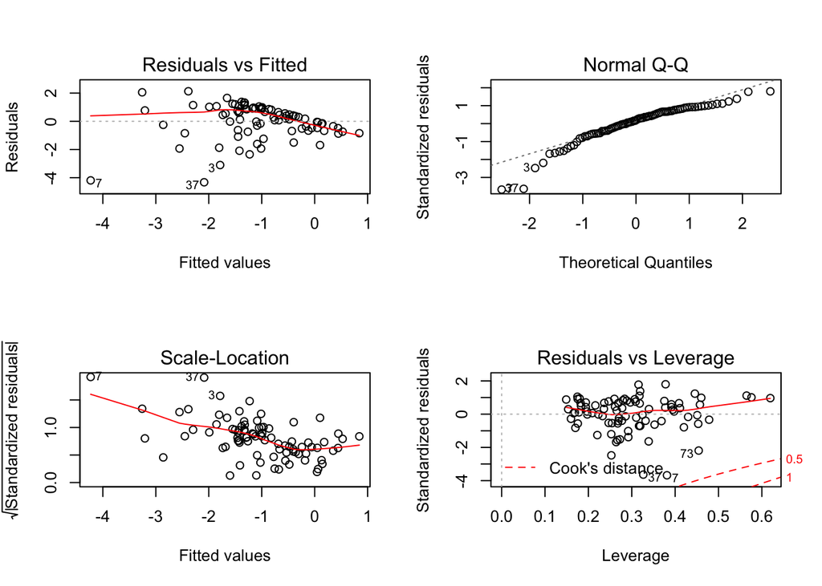

Let’s take out Myanmar, Guatemala, Taiwan, and Malaysia, and redo the regression. Here are the coefficients and their p-values.

```
##                                                               Estimate
## (Intercept)                                                0.560828938
## X2016.EPI.Score                                            0.046361189
## X10.Year.Percent.Change                                    0.019440734
## Environmental.Risk.Exposure                               -0.024337020
## Household.Air.Quality                                     -0.004258687
## Household.Air.Quality...Risk.Exposure                      0.013797241
## Air.Pollution...Average.Exposure.to.PM2.5                 -0.014487383
## Air.Pollution...Average.Exposure.to.PM2.5...Risk.Exposure  0.008212617
## Air.Pollution...Average.PM2.5.Exceedance                   0.019504081
## Air.Pollution...Average.Exposure.to.NO2                   -0.022110066
## Access.to.Sanitation                                       0.030076703
## Unsafe.Sanitation..Risk.Exposure                          -0.018949572
## Access.to.Drinking.Water                                   0.002012261
## Unsafe.Drinking.Water.Quality..Risk.Exposure              -0.017669346
## Wastewater.Treatment                                      -0.009184633
## Nitrogen.Use.Efficiency                                   -0.010581689
## Nitrogen.Balance                                          -0.006131900
## Tree.Cover.Loss                                           -0.001056948
## Fish.Stocks                                                0.018880971
## Terrestrial.Protected.Areas..National.Biome.Weights.       0.036540091
## Terrestrial.Protected.Areas..Global.Biome.Weights.        -0.027023588
## Marine.Protected.Areas                                    -0.001560215
## Species.Protection..National.                              0.012044092
## Species.Protection..Global.                               -0.032422989
## Trend.in.CO2.Emissions.per.KwH                             0.002163566
## Access.to.Electricity                                     -0.014282706
##                                                             Pr(>|t|)
## (Intercept)                                               0.78500295
## X2016.EPI.Score                                           0.42321049
## X10.Year.Percent.Change                                   0.22688653
## Environmental.Risk.Exposure                               0.20803093
## Household.Air.Quality                                     0.77939509
## Household.Air.Quality...Risk.Exposure                     0.51401324
## Air.Pollution...Average.Exposure.to.PM2.5                 0.40727772
## Air.Pollution...Average.Exposure.to.PM2.5...Risk.Exposure 0.26321236
## Air.Pollution...Average.PM2.5.Exceedance                  0.28979931
## Air.Pollution...Average.Exposure.to.NO2                   0.05589238
## Access.to.Sanitation                                      0.02539785
## Unsafe.Sanitation..Risk.Exposure                          0.18859060
## Access.to.Drinking.Water                                  0.82730202
## Unsafe.Drinking.Water.Quality..Risk.Exposure              0.11276097
## Wastewater.Treatment                                      0.35949556
## Nitrogen.Use.Efficiency                                   0.27587576
## Nitrogen.Balance                                          0.19632978
## Tree.Cover.Loss                                           0.84125274
## Fish.Stocks                                               0.02661137
## Terrestrial.Protected.Areas..National.Biome.Weights.      0.12517102
## Terrestrial.Protected.Areas..Global.Biome.Weights.        0.21328762
## Marine.Protected.Areas                                    0.77755037
## Species.Protection..National.                             0.60170904
## Species.Protection..Global.                               0.13768863
## Trend.in.CO2.Emissions.per.KwH                            0.76443145
## Access.to.Electricity                                     0.39769715
```

### Fish Stocks, and Access to Sanitation, Matter

The variable `Air.Pollution...Average.Exposure.to.NO2` is still somewhat significant, with p-value `0.0559`.

But now we have two clearly significant variables. The p-value for `Access.to.Sanitation` is `0.0254`, and the p-value for `Fish.Stocks` is `0.0266`.

The `Access.to.Sanitation` variable measures the percentage of the population that has access to “improved” sanitation, which “hygienically separates human excreta from human contact and is not public or shared, only private”. Furthermore, the coefficient is relatively large at `0.03`. So increasing your population’s access to sanitation by one percentage point is likely to increase your mangrove forest area by 0.03% over twelve years, all other things being held constant.

The `Fish.Stock` variable measures “the fraction of fish stocks overexploited and collapsed by exclusive economic zone”. The goal is to have this down to zero. But the coefficient in my regression is `0.0188`, which means increasing the amount of overexploited fish by 1% is likely to correspond to a 0.0188% increase in your mangrove forests. I would naively expect this coefficient to be negative, so maybe there are confounding variables related to how this variable is measured for each country…?